# French_thinkers

For this assignment, I decided to select the dataset from Homework_4 so that I could once again examine the topic that interests me: the French school of philosophy.

This command was written at the start of the project; it loads the database library and a CSV file, then displays information about the selected data.

```python
# can use to work with tabular data
import pandas as pd
df = pd.read_csv("French.csv")
df.head() # Show the first few rows
df.describe() # Show some basic statistics
```

|  | Birth Year | Death Year |
| --- | --- | --- |
| count | 25.000000 | 25.000000 |
| mean | 1772.960000 | 1834.200000 |
| std | 120.225996 | 122.207133 |
| min | 1533.000000 | 1592.000000 |
| 25% | 1694.000000 | 1755.000000 |
| 50% | 1760.000000 | 1824.000000 |
| 75% | 1908.000000 | 1960.000000 |
| max | 1930.000000 | 2004.000000 |

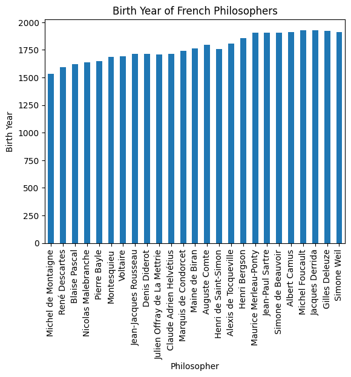

```python
import matplotlib.pyplot as plt
# matplotlib helps to create charts and visualisation
df.plot(kind="bar", x="Philosopher", y="Birth Year", legend=False)
plt.title("Birth Year of French Philosophers")
plt.ylabel("Birth Year")
plt.show()
```

To begin with, I decided to create a chart showing the birth years of the philosophers I selected, in order to illustrate the period when their development as scholars likely began.

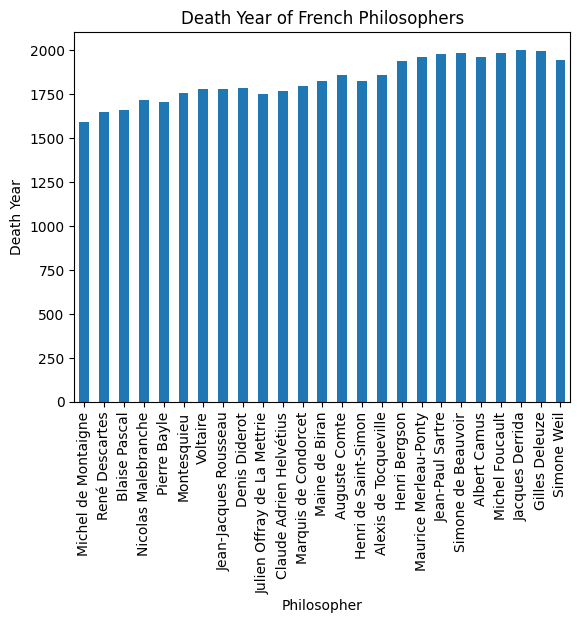

```python
import matplotlib.pyplot as plt
df.plot(kind="bar", x="Philosopher", y="Death Year", legend=False)
plt.title("Death Year of French Philosophers")
plt.ylabel("Death Year")
plt.show()
```

By analogy with the year of birth, I also decided to show the year of death to illustrate when these philosophers might have reached the end of their lives, as well as to perform a count in preparation for the next chart.

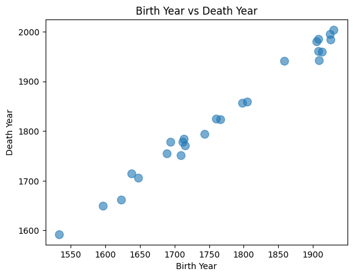

```python
plt.scatter(df["Birth Year"], df["Death Year"], s=90, alpha=0.6)
plt.xlabel("Birth Year")
plt.ylabel("Death Year")
plt.title("Birth Year vs Death Year")
plt.show()
```

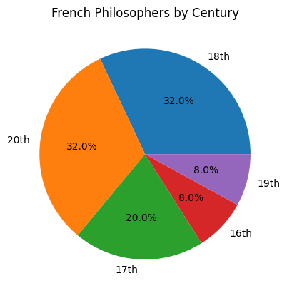

```python
df["Century"].value_counts().plot(kind="pie", autopct="%1.1f%%")
plt.title("French Philosophers by Century")
plt.ylabel("")
plt.show()
```

The pie chart also illustrates the distribution of philosophers across different centuries. Philosophers from the 18th and 20th centuries—as was evident from the previous graph—make up a significant portion of the dataset, whereas the 16th century accounts for only a small fraction. From this, it can be concluded that the dataset primarily covers thinkers from the postRenaissance era.

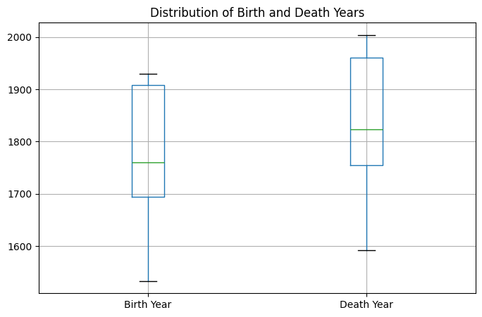

```python
plt.figure(figsize=(8,5))
df[["Birth Year", "Death Year"]].boxplot()
plt.title("Distribution of Birth and Death Years")
plt.show()
```

A box plot also displays the distribution of birth and death years within this dataset. Overall, the wide range of values indicates that the philosophers in question span different historical eras—specifically, from the 16th to the 20th century.

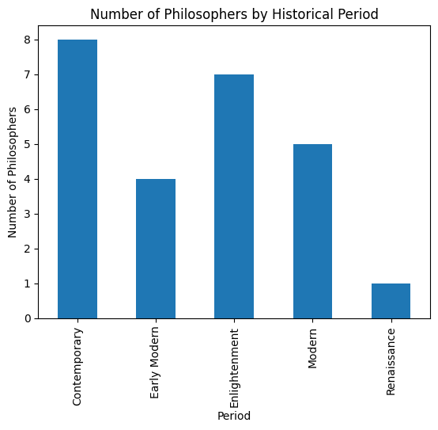

```python
philosophers_by_period = df.groupby("Period")["Philosopher"].count()
philosophers_by_period.plot(kind="bar")
plt.title("Number of Philosophers by Historical Period")
plt.ylabel("Number of Philosophers")
plt.show()
```

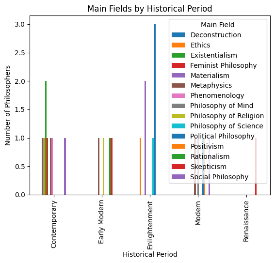

```python
import pandas as pd
import matplotlib.pyplot as plt
period_field = pd.crosstab(df["Period"], df["Main Field"])
period_field.plot(kind="bar")
plt.title("Main Fields by Historical Period")
plt.xlabel("Historical Period")
plt.ylabel("Number of Philosophers")
plt.show()
```